# Prosper Loan Exploration by Tat Cheong Chu

It seems that except with the grade of AA, which is the highest rating, there is no better popularity of investment for the borrowers with higher grade. Most of the boxes just stay at the similar level. But it is mostly because of the outliers. Let we focus the most of the distribution of our data.

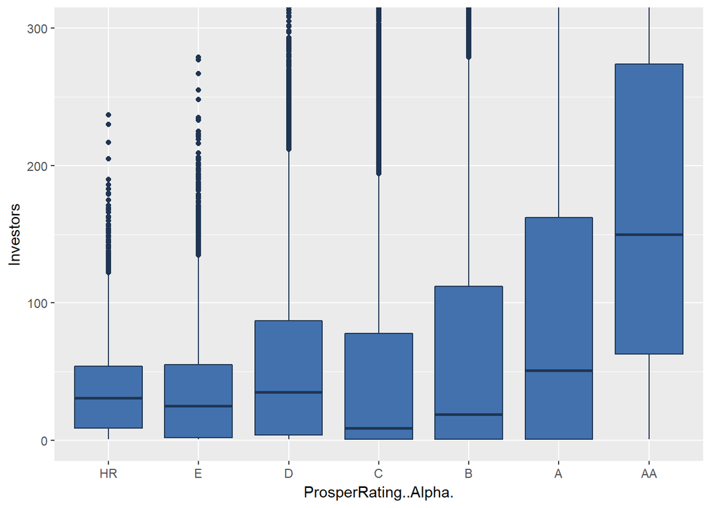

In general, we can say that better grade can bring more investors, especially from the range of grade of C to the AA.

Although the Alpha Rating is not numeric and we can not do correlation calculation with it, the data set prepares the numeric grading for us, whose “1” represents the worst grade “HR” and “7” the best grade “AA” . Its correlation with number of Investors is:

```
## [1] 0.3077531
```

There is another grading system from Prosper - Prosper Score.(https://www.prosper.com/plp/general-prosper_score/)

By reading the explanation from Prosper again, we know that the credit score should be so-called “credit bureau score” or “credit reporting agency score”. Prosper states that the Prosper Score is specifically “A custom risk score was built using historical Prosper data to assess the risk of Prosper borrower listings. The output to Prosper users is a Prosper score which ranges from 1 to 11, with 11 being the best, or lowest risk, score.” In short, it performs a larger spectrum of rating for a clearer examination.

The rating grade is certainly presented on the website of Prosper. But will the investor have the chance to view more precise version of score? Very likely and there is a strong correlation between these two variables.

```
## [1] 0.7052214
```

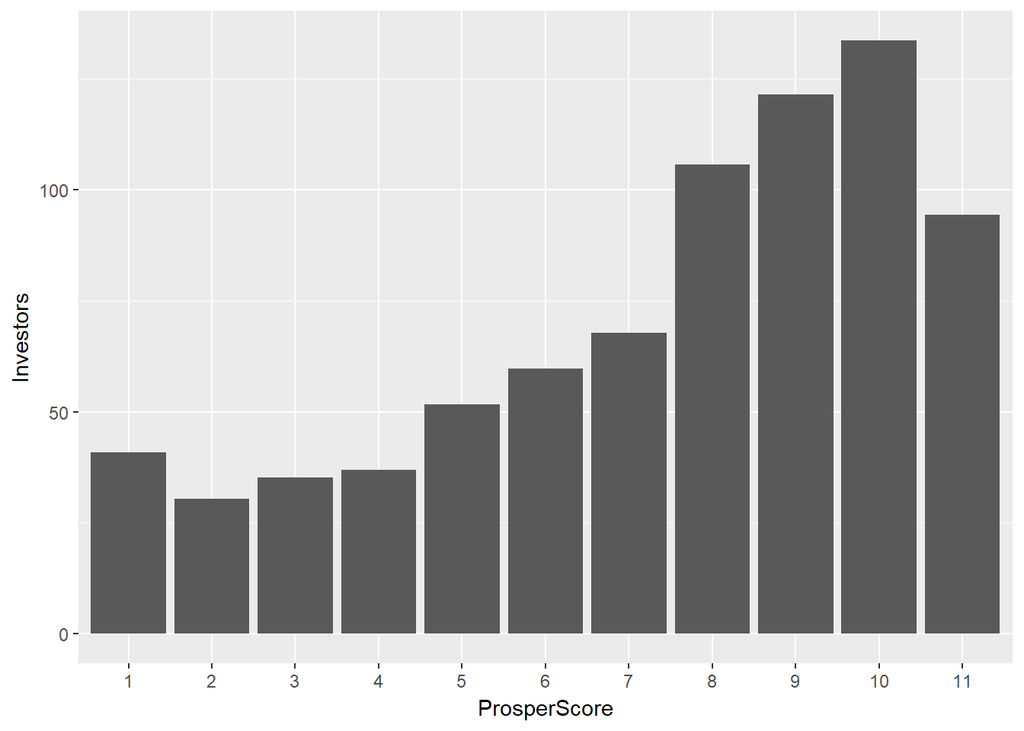

```
## [1] 0.3205938
```

It performs a little bit better than the traditional grading, but two variables don’t act like we expect. The worst grade “1” and the best grade “11” don’t attract the smallest and the largest amount of investors.

The document also talk about the advantage of Prosper Score:

“Unlike a credit bureau score, which is based on a much wider variety of loan performance, the Prosper score is specifically built on the Prosper borrower and applicant population. As such, the credit reporting agency score should, and does, rank order risk on the Prosper population, but is not as discriminating as the custom score.”

Although we have no idea where the data of credit score range come from, it is very likely the so-called “credit bureau score” since every borrower gets his credit score in the two credit score ranges, which are already transformed into the one variable “Average Score”. So how does it perform in predicting the number of investors?

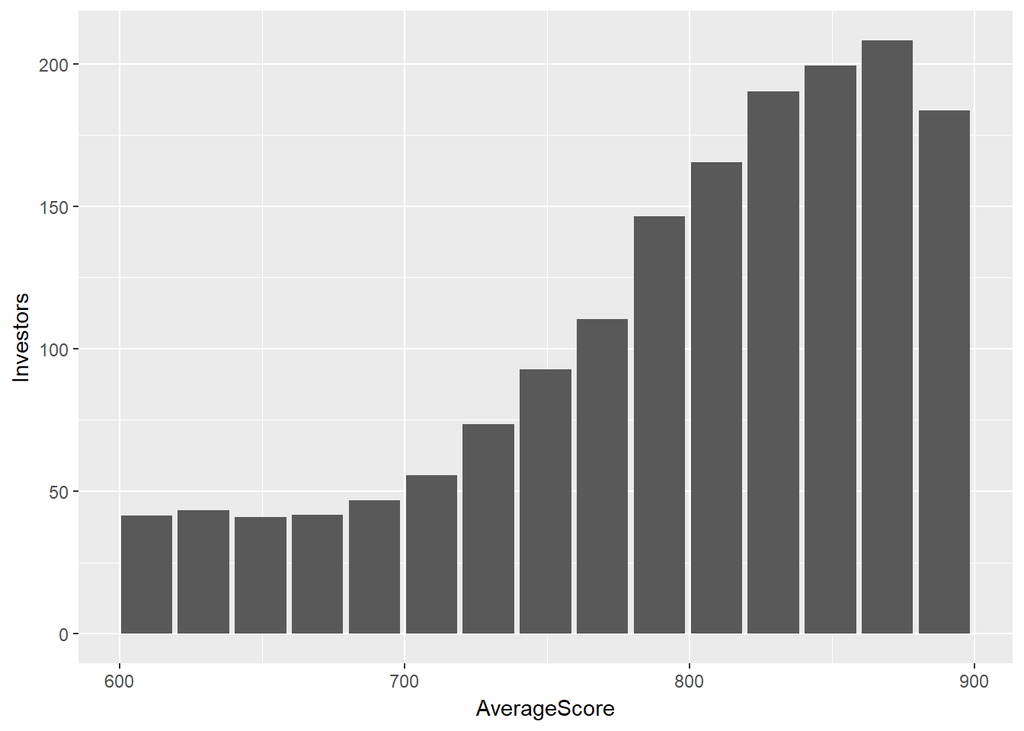

```
## [1] 0.3498367
```

Starting from the average score of 700, the correlation between average score and Investors is very obvious. And it performs even better than the conventional 1-to-7-Rating. But why is the lowest score just about 600? Let’s come back to our full data set:

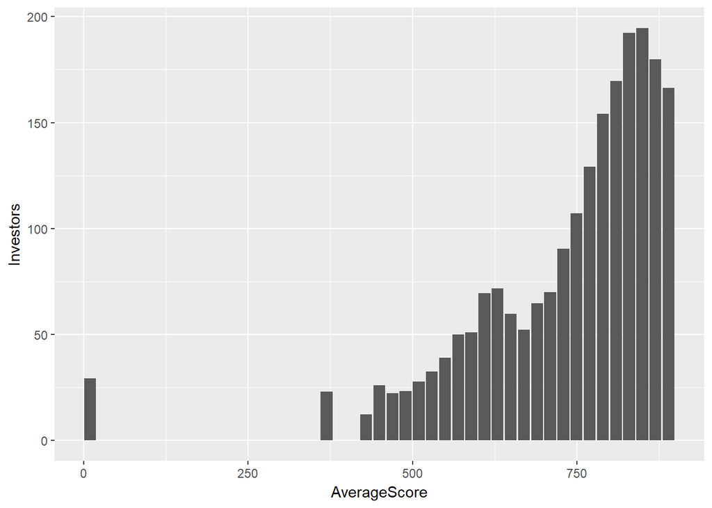

```
## [1] 0.27135
```

It performs now below the standard of “good” correlation, i.e. 0.3. As we see in the graph, some borrowers with very low scores can still win some investors.

The very low scores are excluded after I filter the full data set where the Prosper conventional Rating is missing, that means, only the one whose credit range is approximately over the level of 600 can own a prosper score. Otherwise, the value of Prosper’s conventional rating will be blank.

It also means that, A HR borrower may be someone who actually earns an average score more than 600. It is very strange because let’s say the most famous credit score – FICO score, whose ranges from 300 to 850, the level of 600 is actually just a bit worse than having a good credit history. https://www.investopedia.com/terms/f/ficoscore.asp

```
##     CreditGrade
## 3            HR
## 43           HR
## 69            E
## 77            E
## 102           E
## 114          HR
```

Some of data which have lower than the level of 600 have Credit Grade. Again, we don’t know where does this grade come from. And when was it generated? Before the origination of loan? After the origination? Or never and is it just an internal record in Prosper’s database?

If it is not shown in front of the investors, how come there is still a correlation between Average Score and number of investors? I think the best explanation is that there is also a relationship between the Prosper Rating (traditional or Prosper Score) and Average Score. The first one is the corrletation between Prosper conventional Rating (1 to 7 version) and Average Score; the second one is between Prosper Score (1 to 11 version) and Average Score:

```
## [1] 0.5488738
```

```
## [1] 0.369603
```

The connection between the Average Score and Prosper Rating is stronger than between Average Score and Prosper Score. Maybe the history of the rating development should be like this:

Credit Grade/Credit Score (from bureau?) –> Prosper conventional rating –> Prosper Score

Since we can be sure that the last two will be shown in the investors’ pages, we should include them if we want to investigate the predictive factor of investors.

Let’s back to the focus on investors. How is the relationship between the Monthly Income and number of Investors?

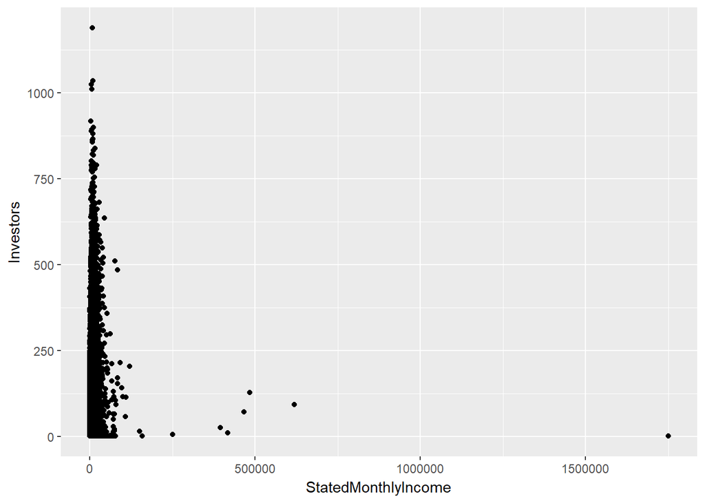

There are some super rich people who produce huge outliers on the scatter plot. Let’s zoom in a little bit:

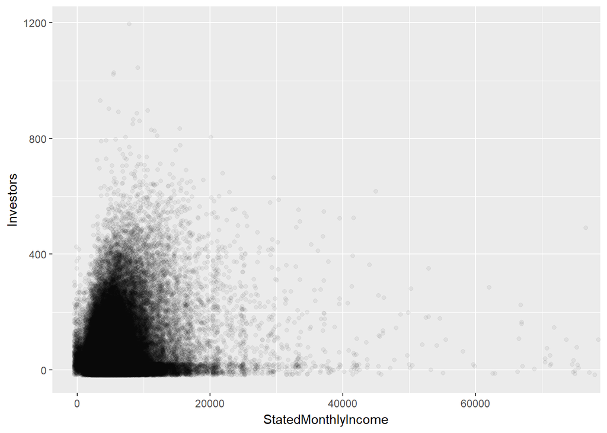

It reminds me that the form we have seen in the uni-variable analyze, whose peak appears in the left hand side. We need to add the data into the log10 function again:

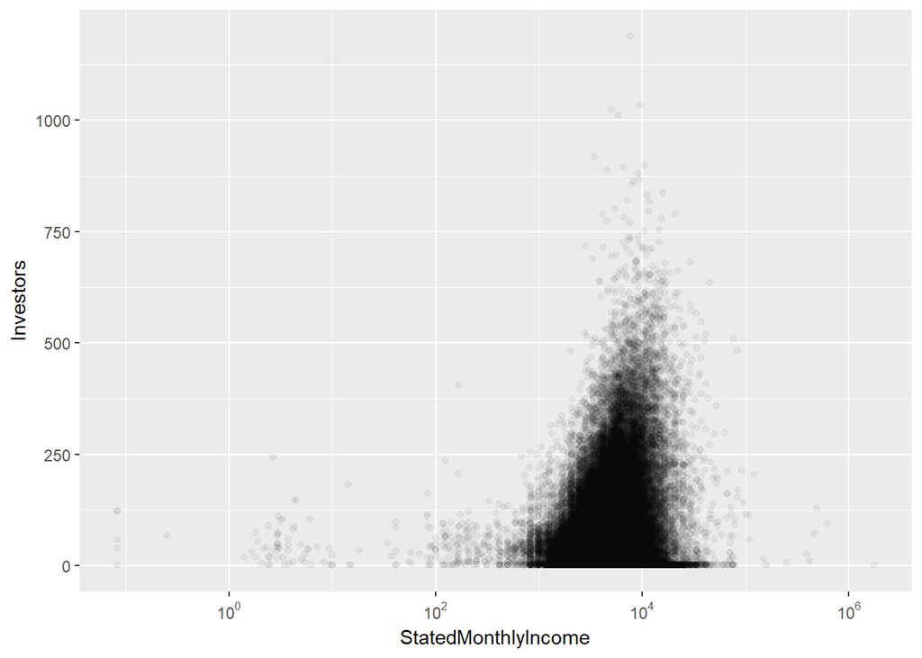

Again, the distribution concentrate around 10^4 like the uni-variable. I think it is just because most of borrowers earn the intermediate income, so most of investors have more chances to invest in these people’s loans. In fact, there are almost no correlation between these two factors.

```
## [1] 0.125213
```

But how is correlation between Monthly Income and score? How much do I earn should be related to the score, which affects the investors? In order to have a fair analyse, I only include the verified Income data in the subset during calculating the correlation:

Correlation with Prosper Conventional Rating:

```
## [1] 0.1607495
```

Correlation with Prosper Score:

```
## [1] 0.1567097
```

Correlation with Average Score:

```
## [1] 0.1641907
```

None of our grading systems seem to have the relationship with Monthly Income.

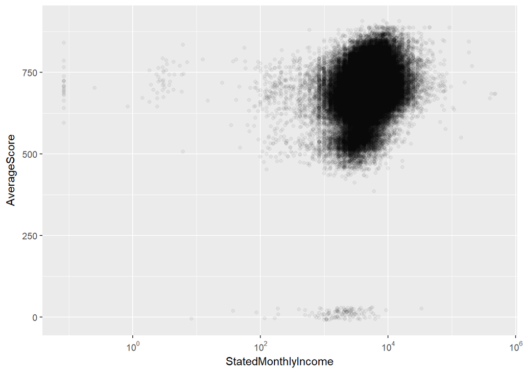

Reading the document on Prosper again, Key variables of Prosper Score in the scorecard are:

- Number of inquiries on the credit bureaus
- Number of delinquent accounts on the credit bureau
- Credit card utilization on the credit bureau
- Number of recently opened trades on the credit bureau
- Debt to income ratio
- Loan payment performance on prior Prosper loans

Although many similar factors like “previous credit” are included in our data set, lots of them are just 0 and lack of variety.

It reminds me that we have the variable of “Debt To Income Ratio”. Maybe it can be a better statement since it considers the factor of the proportion between income and loan.

Correlation with Investors:

```
## [1] -0.006711091
```

Correlation with Prosper Score:

```
## [1] -0.1455127
```

It does not perform better.

It is against my intuition: when we len money to the others, we will examine if the borrowers have the ability to pay the money back.

Then what is the factor which affects the score the most? Then I come back to the matrix of correlation and find the strongest correlation with the score: The Lender Yield.

```
## [1] -0.6497835
```

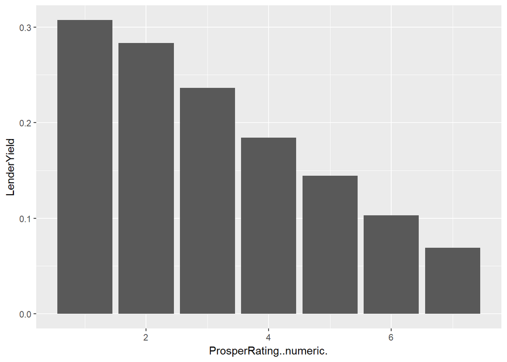

It perfectly related to……how much can the investors earn?

It should be better to say: the score affects the yield, since people with bad score should pay higher interests. According to the theory in Economics, people with bad credit score are likely not able to pay back in the future, so they need to pay more to balance the risk and uncertainty in the future.

# Bivariate Analysis

### Talk about some of the relationships you observed in this part of the investigation. How did the feature(s) of interest vary with other features in the dataset?

There are a correlation between the investors and loan original amount, even though the amount number just sticks to a particular number and therefore lacks of variety. It is understandable because large amount of loan needs more people to fill the requirement. It may show that investors want to avoid risk rather than throwing more investments and expecting better returns.

The correlation between investors and lender yield is weak (-0.24232616). The negative correlation indicate that when the lender yield goes up, the number of investors will move down. I think the reason is that higher return also means higher risk.

### Did you observe any interesting relationships between the other features (not the main feature(s) of interest)?

The relationship between the score system, whatever it is from the rating system in Prosper or the “bureau score”, and the level of income is almost equal to zero. It doesn’t make sense to me because how much borrowers can borrow should be proportional to how much borrowers can earn.

### What was the strongest relationship you found?

The relationship between Lender Yield and Prosper Conventional Rating is very strong, almost reaching the maximum level of correlation. Because at the first beginning, the Lender Yield refers to the Credit Score, since the credit indicates how trustful the borrowers are. If they are more untrustful, then they need to pay more transaction costs.

But again, the question “what affects the score most?” has not been answered. Assuming the score system is reasonable and it reveals the information the lenders need to know, other factors like the past record determine more and subtle changes like past-due once will make a huge difference in the score or rating.

Since this exploration is focusing the relationship between investors and other variables, we will go back analyzing the main theme in the next section.

# Multivariate Plots Section

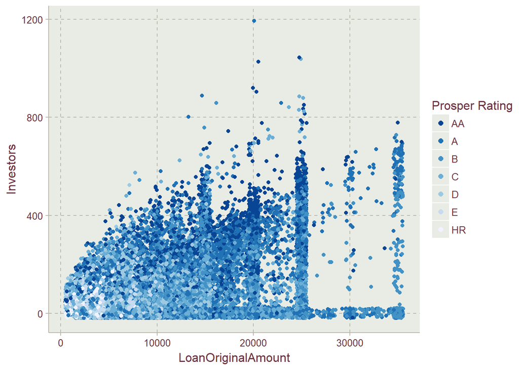

High grades like AA and A, whose colors are the darkest, spread within different loan amount and numbers of investors in the whole pictures. Though some of them may not attract large of amount of investors, they generally gain more investors than the others with the same amount of loan. Especially for the loan amount over than 25000, a A-Grade borrower need more investors likely than a B-Grade borrower.

Grade of E and HR, whose colors are the lightest, spread only around the area of low loan amount and stop at some amountx.

In order to see the exact differences between those grades, we can split the data into 7 blocks according to their grades:

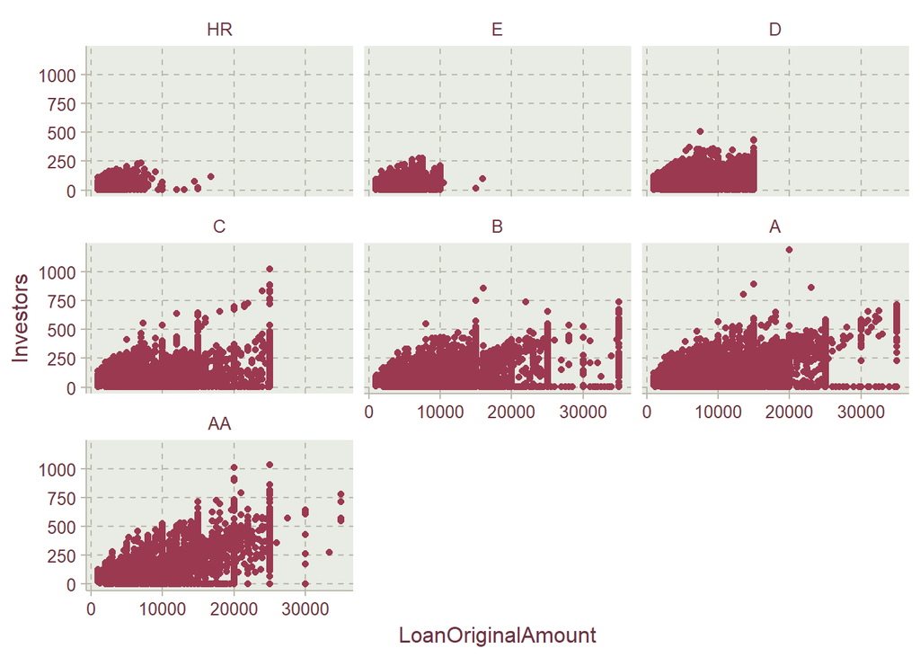

The most obvious differences of grades is that the better grades will borrow more money than the worse. I suspect it is a kind of a policy which limits the low grade borrowers to borrowe more money. Borrowers with D-grade stop at the amount of 15000 and the one with C-grade at 25000 with the very clean horizontal lines.

Thirdly, it is interesting that AA-grade borrowers are not “active” to borrow loan which is more than 25000.

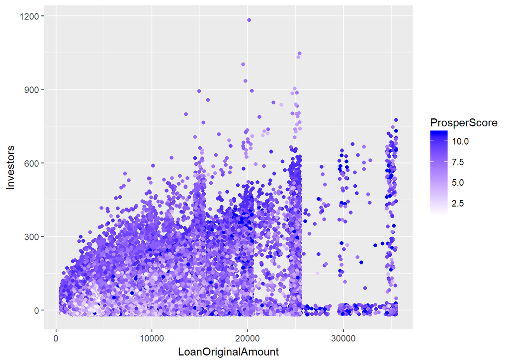

If we shift to the system of Prosper Score, the similar trend will appear again: high grade will not guarantee to have more investors, but will guarantee higher possibility to have. If we ignore the importance of the outliers which is over 600 investors, the clear dark-blue curve is over the other data points.

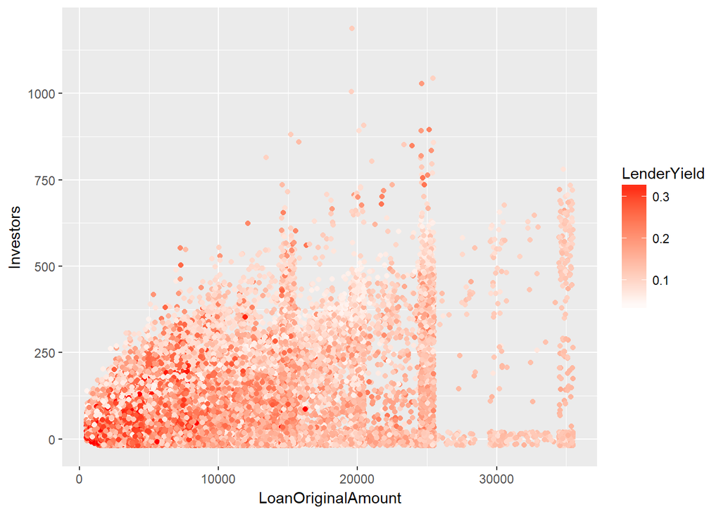

For the large Amount of loan more than 25000, people lend money at a low rate yield. At the most time, the darkest red points, i.e. the highest yield rates, just concentrate the loan which is under 15000.

And we can also find that low rates of yield have a wide range of numbers of investors, we can see the light points spread out forming straight lines horizontally in different amounts of loan. A more interesting thing is that the high Lender Yield may have chance to have many investors, especially for the large amount of loan up to 25000.

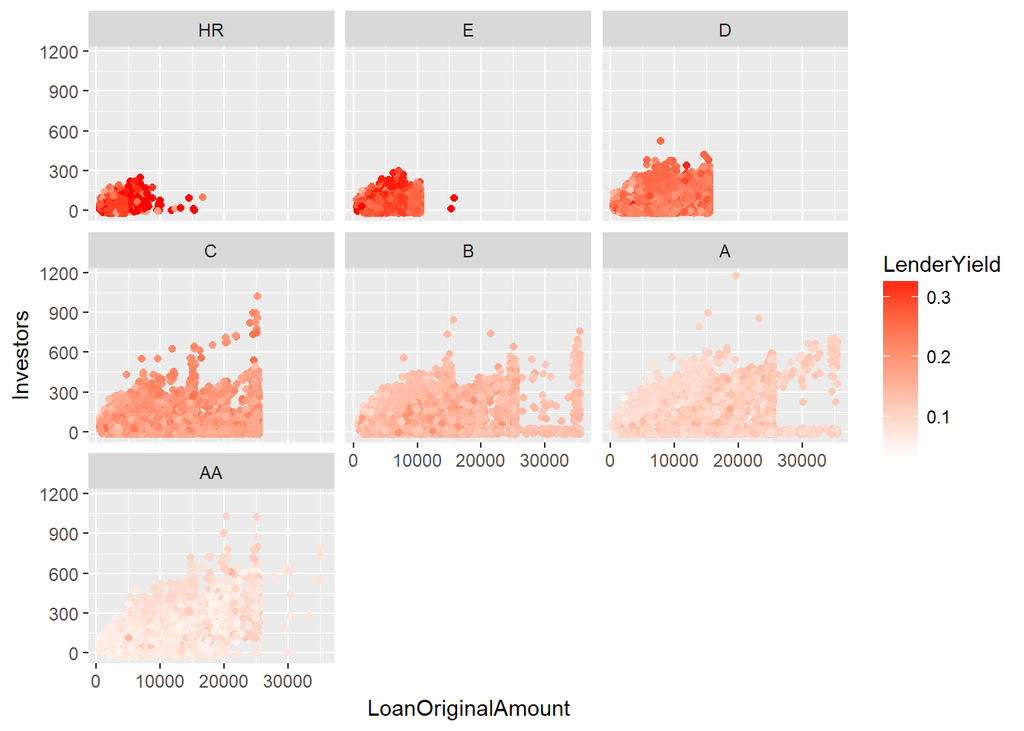

Since there is a strong correlation between grade and lender yield, the color gets lighter while the grade gets better.

As we can see, some dark points which climb up to the level of 1000 in the number of investors appear to be the C-grade borrowers, which pay at a intermediate rate of Lender Yield.

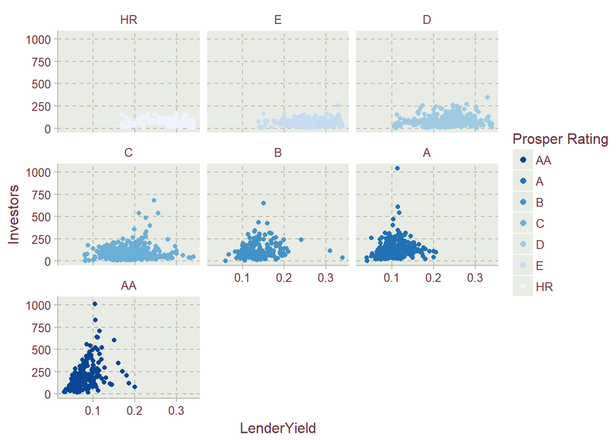

Even on the same level of yield, the AA-grade borrowers are likely to gain more investors.

Can we say borrowers with top grade is more attractive to the investors? Maybe not. At this time, I thoroughly reconsider the aim of this research, doubting the meaning of predicting the number of investors. When we investigate the number of investors, it is more accurate to ask the question in this way: “how many investors do a loan need to fulfill its requirement of loan amount?”

Because people may be attracted by the loan and invest with a great amount of money, but we can not going to say that the investment is not “attractive” since there are limited places for investing a P2P loan. So I find that the concept of “attraction” I used before is a bit misleading. High amount of investors may just represent one side of “attraction”, which appeals the investors who prefer investing in small amount.

Next, I want to see the another side of “attraction” of the loan : averagely, how much an investor have invested.

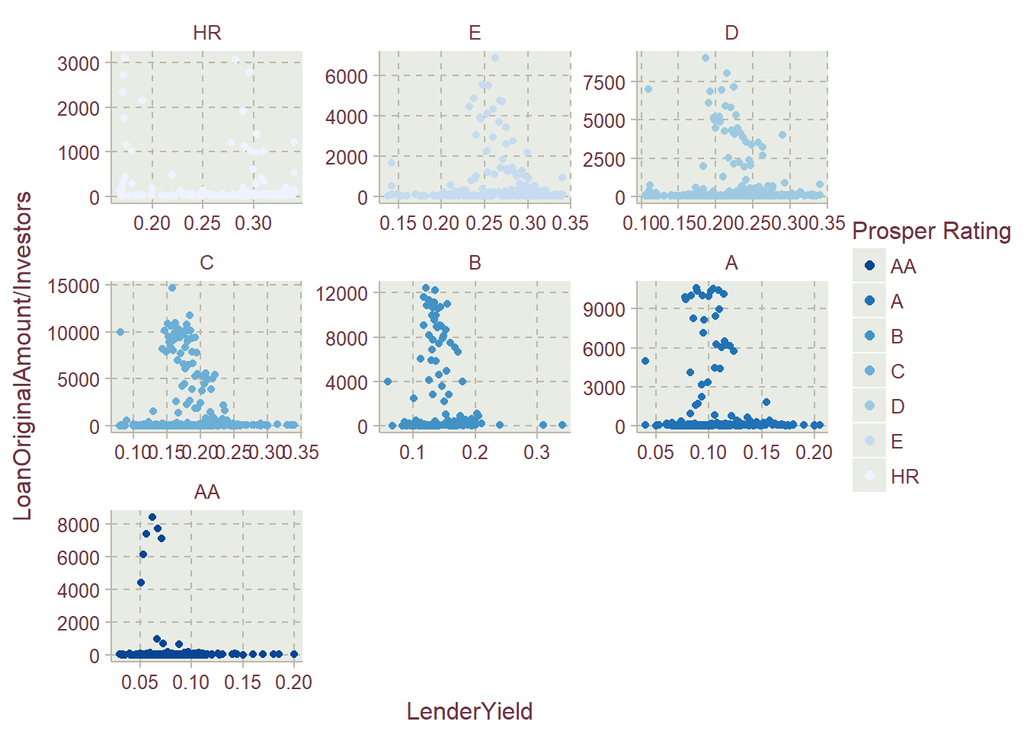

The differences of outliers between different grades become so obvious. From HR-grade to C-grade, investors are going to invest more and more. From C-grade to AA-grade, the amount of individual investment start to shrink. But we should notice there are vertical straight lines staying on the ground in every graphs, indicating that the majority of investors just want to invest in a small number.

What will happen if we include the consideration of loan terms?

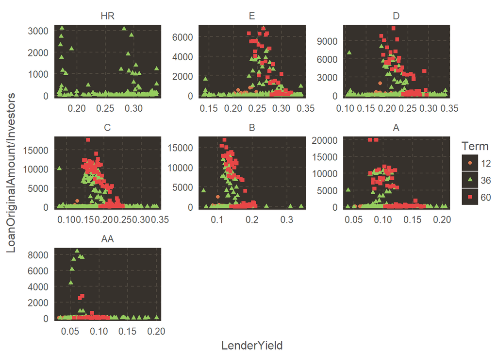

In general, C-grade and B-grade can attract investors to invest in larger amount across different rates of yield in 36-term and 60-term. Unlike A-grade, they just don’t hit the peak of the numbers when their number is split into three categories.

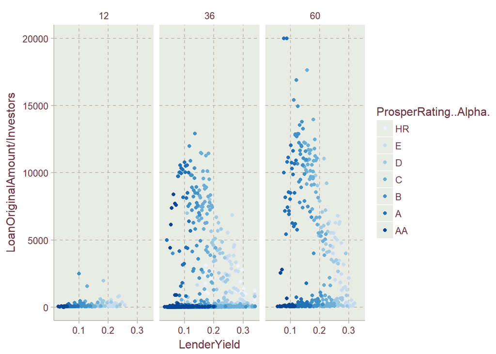

Some of the people may want to invest in borrowers with A-grade with huge amount of money if they are going to invest in a long term in 5-year-loan. I think it is because people want to balance the need of safe investment and more return in a long-term investment. But the density of A-grade points are actually similar to the density of B-grade, showing the peak may be just the minority.

In the term of 36, The density of A-grade line are more similar to lines from B-grade C-grade.

And it is also funny to observe that the changes of investment amount of a investor. The differences between the 1-year-loan and 3-year-loan is much huge than 3-year-loan and 5-year-loan.

Lastly, I try using a linear model to see if we can find the way to predict the number of investors and the amount of loan in the linear regression:

Predicting the number of invesotrs:

```
##
## Calls:
## m1: lm(formula = Investors ~ LoanOriginalAmount, data = simplified_pLD_numeric)
## m2: lm(formula = Investors ~ LoanOriginalAmount + ProsperRating..numeric.,
##     data = simplified_pLD_numeric)
## m3: lm(formula = Investors ~ LoanOriginalAmount + ProsperRating..numeric. +
##     ProsperScore, data = simplified_pLD_numeric)
## m4: lm(formula = Investors ~ LoanOriginalAmount + ProsperRating..numeric. +
##     ProsperScore + LenderYield, data = simplified_pLD_numeric)
## m5: lm(formula = Investors ~ LoanOriginalAmount + ProsperRating..numeric. +
##     ProsperScore + LenderYield + Term, data = simplified_pLD_numeric)
## m6: lm(formula = Investors ~ LoanOriginalAmount + ProsperRating..numeric. +
##     ProsperScore + LenderYield + Term + AverageScore, data = simplified_pLD_numeric)
##
## ========================================================================================================================================
##                                   m1                 m2                m3                m4                m5                m6
## ----------------------------------------------------------------------------------------------------------------------------------------
##   (Intercept)                      28.096***        -11.810***        -28.910***       -266.005***       -276.902***       -565.939***
##                                    (0.472)           (0.810)           (0.867)           (4.756)           (4.712)           (6.364)
##   LoanOriginalAmount                0.006***          0.003***          0.004***          0.004***          0.004***          0.004***
##                                    (0.000)           (0.000)           (0.000)           (0.000)           (0.000)           (0.000)
##   ProsperRating..numeric.                            11.914***          2.722***         31.854***         38.401***         28.508***
##                                                      (0.201)           (0.269)           (0.633)           (0.644)           (0.646)
##   ProsperScore                                                          8.938***          8.015***          7.633***          8.015***
##                                                                        (0.178)           (0.176)           (0.174)           (0.170)
##   LenderYield                                                                           664.761***        825.908***        767.572***
##                                                                                         (13.119)          (13.500)          (13.200)
##   Term                                                                                                     -1.202***         -1.148***
##                                                                                                            (0.028)           (0.027)
##   AverageScore                                                                                                                0.476***
##                                                                                                                              (0.007)
## ----------------------------------------------------------------------------------------------------------------------------------------
##   R-squared                         0.144             0.138             0.163             0.187             0.205             0.243
##   adj. R-squared                    0.144             0.138             0.163             0.187             0.205             0.243
##   sigma                            95.491            88.400            87.112            85.824            84.892            82.814
##   F                             19239.823          6775.188          5493.956          4887.001          4370.421          4545.800
##   p                                 0.000             0.000             0.000             0.000             0.000             0.000
##   Log-likelihood              -681111.252       -500699.647       -499454.079       -498189.256       -497262.951       -495159.621
##   Deviance                 1038923915.971     663060310.771     643876994.641     624964972.163     611467880.533     581893002.497
##   AIC                         1362228.505       1001407.294        998918.159        996390.512        994539.902        990335.243
##   BIC                         1362257.435       1001444.689        998964.902        996446.604        994605.342        990410.032
##   N                            113937             84853             84853             84853             84853             84853
## ========================================================================================================================================
```

Predicting the lending amount of an invesotrs:

```
##
## Calls:
## m1: lm(formula = LoanOriginalAmount/Investors ~ ProsperRating..numeric.,
##     data = simplified_pLD_numeric)
## m2: lm(formula = LoanOriginalAmount/Investors ~ ProsperRating..numeric. +
##     AverageScore, data = simplified_pLD_numeric)
## m3: lm(formula = LoanOriginalAmount/Investors ~ ProsperRating..numeric. +
##     AverageScore + ProsperScore, data = simplified_pLD_numeric)
## m4: lm(formula = LoanOriginalAmount/Investors ~ ProsperRating..numeric. +
##     AverageScore + ProsperScore + LenderYield, data = simplified_pLD_numeric)
## m5: lm(formula = LoanOriginalAmount/Investors ~ ProsperRating..numeric. +
##     AverageScore + ProsperScore + LenderYield + Term, data = simplified_pLD_numeric)
##
## =========================================================================================================================================
##                                     m1                    m2                    m3                    m4                    m5
## -----------------------------------------------------------------------------------------------------------------------------------------
##   (Intercept)                        666.409***          13264.865***          14667.368***          34060.175***          34699.401***
##                                      (56.359)             (353.254)             (351.283)             (460.185)             (445.614)
##   ProsperRating..numeric.            765.223***           1066.524***           1599.636***           -981.228***          -1871.477***
##                                      (12.801)              (15.198)              (19.725)              (45.113)              (45.247)
##   AverageScore                                             -19.503***            -20.162***            -18.156***            -17.826***
##                                                             (0.540)               (0.535)               (0.523)               (0.507)
##   ProsperScore                                                                  -522.080***           -439.565***           -379.579***
##                                                                                  (12.494)              (12.278)              (11.914)
##   LenderYield                                                                                       -58035.940***         -75710.528***
##                                                                                                       (917.186)             (918.468)
##   Term                                                                                                                       133.755***
##                                                                                                                               (1.776)
## -----------------------------------------------------------------------------------------------------------------------------------------
##   R-squared                            0.040                 0.055                 0.074                 0.116                 0.171
##   adj. R-squared                       0.040                 0.055                 0.074                 0.116                 0.171
##   sigma                             6239.338              6191.953              6129.240              5989.585              5798.891
##   F                                 3573.314              2466.421              2260.173              2776.065              3503.945
##   p                                    0.000                 0.000                 0.000                 0.000                 0.000
##   Log-likelihood                 -861899.105           -861251.732           -860387.445           -858431.198           -855685.240
##   Deviance                 3303193014658.123     3253173198977.334     3187571977806.241     3043932944513.795     2853161551588.887
##   AIC                            1723804.210           1722511.464           1720784.890           1716874.396           1711384.480
##   BIC                            1723832.256           1722548.859           1720831.634           1716930.488           1711449.921
##   N                                84853                 84853                 84853                 84853                 84853
## =========================================================================================================================================
```

Although we have observe some kinds of patterns in our graph, the R-squared scores are quite low in both of the models and we cannot predict their numbers in the way of linear regression.

# Multivariate Analysis

### Talk about some of the relationships you observed in this part of the investigation. Were there features that strengthened each other in terms of looking at your feature(s) of interest?

In short:

- If a borrower borrows with relatively huge amount and has a good grade, he is more likely to need lots of investors to fulfil the loan origination in general.
- If a borrower has a C-grade, he is going to have fewer investors but with larger individual investment.
- If a borrower has the rating from A-grade to C-grade and demands a 5-year-loan, he is more likely to gain investors who prefer larger individual investment.

### Were there any interesting or surprising interactions between features?

No matter whether the investors want to invest with small amounts or large amounts, lots of people seem to prefer the intermediate grade “C”. I think the reason is because it is exactly “intermediate”: intermediate return and risk. People with C-grade need to pay more for their interests and is not going to fail paying the loan comparing grades like D and E.

So……maybe this is the reason why every time I click into the page of Prosper-Invest, I can see the recommendation of C-grade loan stand in the middle of choices.

### OPTIONAL: Did you create any models with your dataset? Discuss the strengths and limitations of your model.

I have created a linear model and don’t think it is helpful. As we can see, people borrow and lend in their different preferences.

It is true that many low grade borrowers don’t borrow a lot and gain so few investors, but this may be also something happening to some of the high grade borrowers. Therefore we can observe the points and lines get up and down in the line graph, no matter how great their grades are.

# Final Plots and Summary

### Plot One

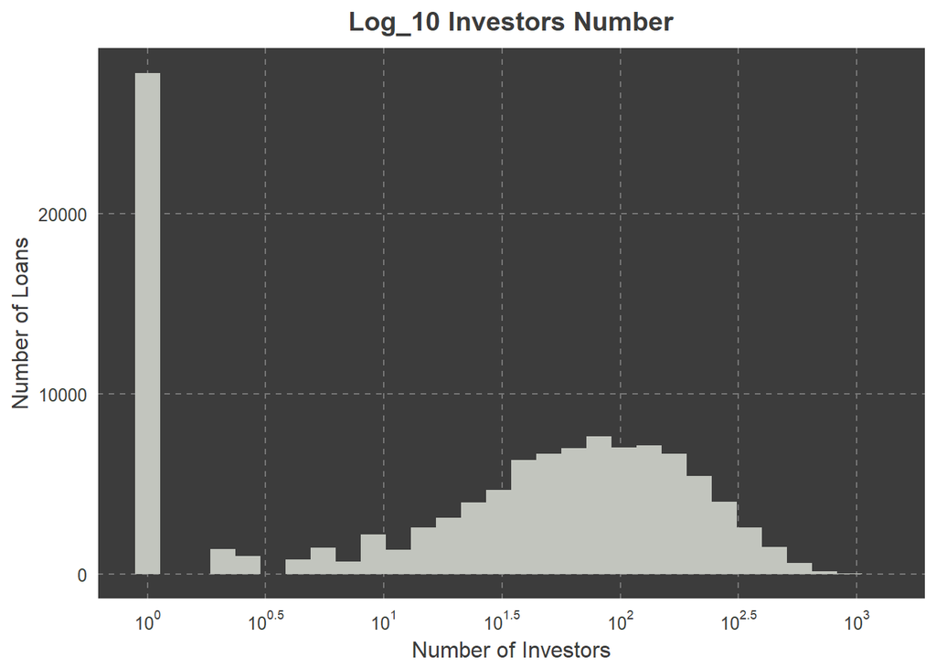

### Plot Two

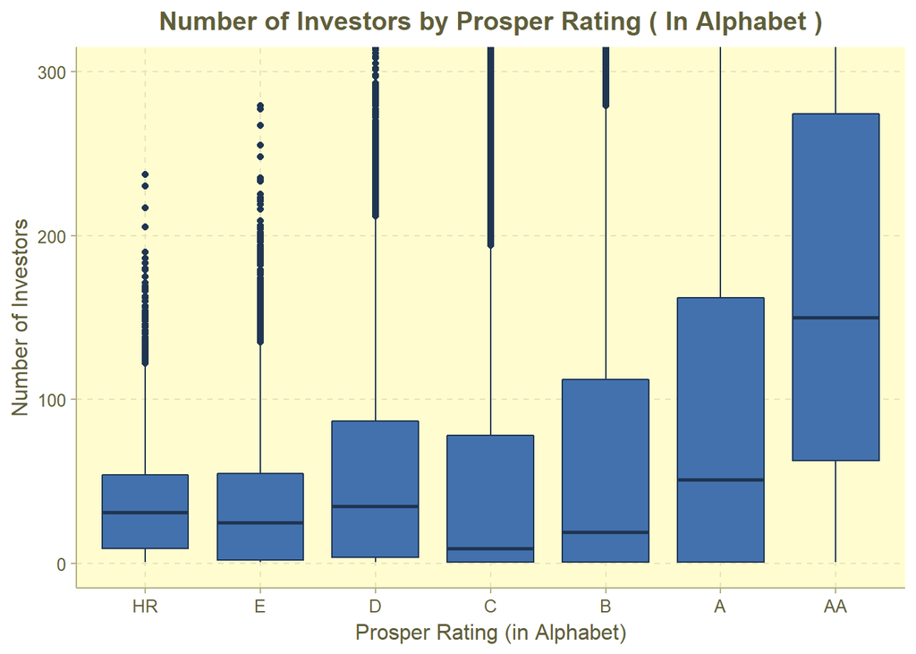

### Plot Three

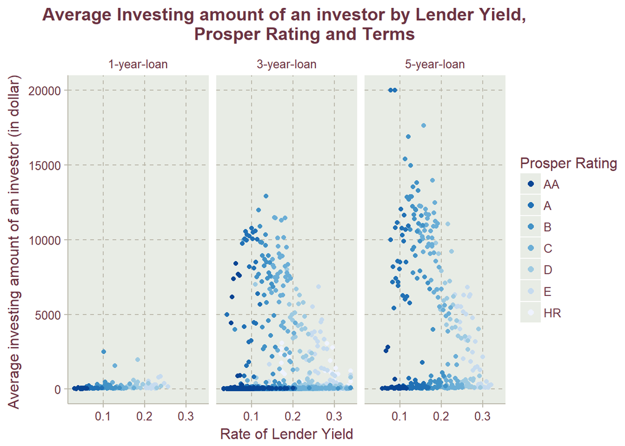

### Description Three

1-year-loan can only attract lenders to invest in very small amounts individually. But 3-year-loan and 5-year-loan can attract much more of this kind of individuall investments. In both situations, the density of individuall investments on AA-Grade, the greatest rating, is not higher than A-, B- or C-Grade.

Interesting is, the differences between the amounts of 3-year-loan and 5-year-loan are not as huge as between the amounts of 1-year-loan and 3-year-loan, even though the durations increase by 2 years in both cases.

# Reflection

The successful thing in this analyze is to review the meaning of different variables in the data set in an overall perspective, because this data set is just too big and we are not going to investigate every variables. I may put too much time on reviewing many variables in uni-variable analyze, but this way of research helps analysts to rethink what is the most interesting part in the dataset.

The frustrating thing is that the journey of uni-variable analyze seemed endless to me at the first beginning. You need to pick some variables from the data set, but why these rather than the others ? Is there a logic to present the data in a more reasonable way rather than picking them according to personal preferences ? At last, I analyze them in the time line of how a loan is created. It appears to have a better result in order to understand the system of Prosper.

Also, at first I lack of thoughts about the meaning of number of investors and once question whether I should restart my research at some points. But it is just a different way to see the problem, because huge number of investors also means that it attracts people to invest in small amounts, so there will be more places for more participants.

I hope at the end, everything looks good.

I think there is also an option to examine the topic of “attraction”. We have the variables of the “LoanOriginationDate” and “ListingCreationDate” in the data set. The first one states when the loan is successfully issued and the second one states when it is listed on the website, waiting for the investment. The differences between these two dates can be interpreted as: how fast is the loan proposal fully accepted?

I hope one day I can find the mystery of the credit score as, if I have time to do so. This project really takes time and it is not as easy as I thought before.